# Sumário executivo para a gestão

Diagnóstico institucional e operacional do assessoramento às escolas — anos iniciais

Autor

Unidade de Ensino Fundamental — SMED/PMPA

Data de Publicação

3 de agosto de 2026

**ImportanteLeitura obrigatória**

Este sumário apresenta um diagnóstico **observacional e descritivo**. Não identifica efeitos causais do assessoramento. A avaliação de 2025 representa linha de base anterior ao programa, com **dose zero**. Resultados educacionais pertencem ao contexto das escolas, não compõem o índice operacional e não avaliam a atuação das assessoras.

# Mensagem central

A UEF-SMED dispõe agora de uma base institucional consistente para enxergar simultaneamente a **rede**, as **escolas** e a **composição das carteiras de assessoramento**. O principal achado gerencial não é a existência de uma classificação única de escolas ou assessoras, mas a presença de **heterogeneidades relevantes que o simples número de escolas por carteira não captura**.

O universo institucional possui **56 escolas**, mas somente **53** representam carga operacional de assessoramento em 2026. As demais **3** permanecem importantes para a caracterização da rede, sem serem tratadas como demanda operacional.

As carteiras combinam escolas de portes, estruturas e complexidades distintas. Por isso, decisões sobre divisão de trabalho devem considerar conjuntamente **volume**, **estrutura** e **complexidade administrativa**, complementados pelo conhecimento qualitativo da equipe e, futuramente, por medidas diretas da dose de assessoramento.

# O que a gestão precisa reter

### Universo operacional

**Leitura.** 53 das 56 escolas representam carga operacional em 2026.

**Implicação gerencial.** Manter separados os universos institucional, operacional, avaliativo e gerencial.

### Heterogeneidade das escolas

**Leitura.** A rede reúne diferenças relevantes de porte, estrutura, atendimento e complexidade administrativa.

**Implicação gerencial.** Planejar apoio e prioridades com base em perfis multidimensionais, não apenas no número de escolas.

### Composição das carteiras

**Leitura.** As 11 carteiras diferem em extensão, volume e combinação de dimensões operacionais.

**Implicação gerencial.** Revisar a distribuição por meio de discussão técnica, sem ranking ou redistribuição automática.

### Resultados educacionais

**Leitura.** A participação aumentou, mas cobertura e composição mudaram entre 2025 e 2026.

**Implicação gerencial.** Usar os resultados para diagnóstico pedagógico; não para avaliar assessoras nem inferir impacto causal.

### Métrica de esforço

**Leitura.** O índice operacional é uma aproximação relativa e parcial; não equivale a horas trabalhadas.

**Implicação gerencial.** Implantar registro padronizado de visitas, duração, deslocamento, modalidade e finalidade.

# Rede e universos

A rede analisada reúne aproximadamente **20.459 matrículas**, **869 turmas** e **1.299 docentes** nos anos iniciais. A escola mediana possui **378 matrículas**, e a média ponderada é de **23,4 estudantes por turma**.

Cerca de **18,5%** das matrículas são de tempo integral e **8,4%** correspondem à educação especial. O índice médio de infraestrutura é **90,0**, mas **52 escolas** apresentam alerta de composição entre as avaliações de 2025 e 2026.

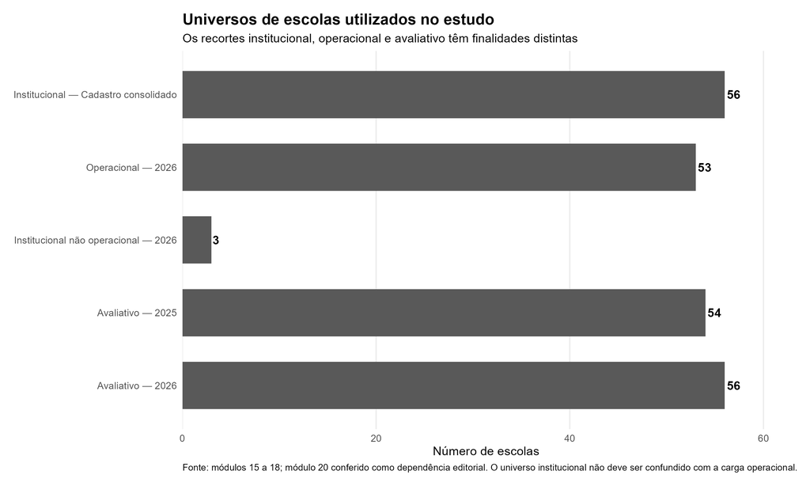

Figura 1: Universos institucionais, operacionais e avaliativos

A separação dos universos é uma regra de governança:

- **institucional:** caracteriza a rede;
- **operacional:** representa demanda de assessoramento em 2026;
- **avaliativo:** delimita a cobertura das avaliações;
- **gerencial:** organiza a descrição das carteiras.

Misturar esses universos produziria conclusões incorretas sobre carga, cobertura e resultados.

# Participação e resultados educacionais

O universo avaliativo passou de **54 escolas em 2025** para **56 em 2026**. A participação agregada estimada aumentou de **77,5%** para **85,6%**, uma variação aproximada de **8,1 pontos percentuais**.

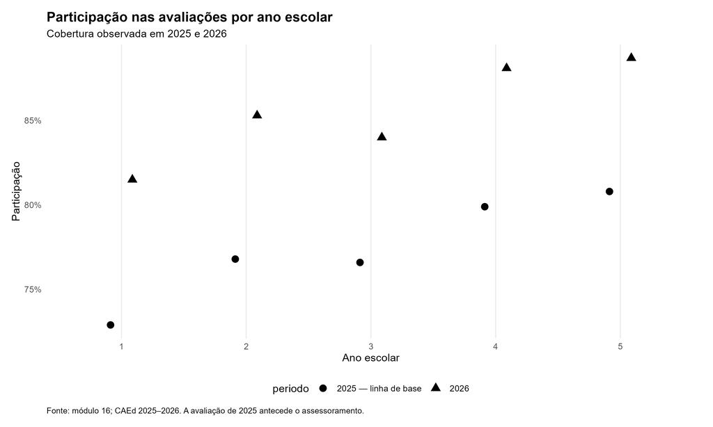

Figura 2: Participação nas avaliações por ano escolar

O aumento da participação é institucionalmente relevante porque amplia a cobertura do diagnóstico. Ao mesmo tempo, altera a composição observada. As diferenças de proficiência entre 2025 e 2026 devem, portanto, ser lidas com cautela:

1. 2025 antecede o assessoramento;
2. a cobertura não é constante;
3. as populações avaliadas podem diferir;
4. não existe medida individualizada e completa da dose recebida;
5. o desenho atual não identifica efeito causal.

A utilização gerencial mais segura é orientar perguntas pedagógicas e prioridades de acompanhamento, jamais atribuir os resultados às assessoras.

# Carteiras: diferenças que o número de escolas não mostra

As **11 carteiras gerenciais** abrangem **53 escolas operacionais**.

Entre as carteiras, observa-se:

- de **4 a 6 escolas**;
- de **1.261 a 2.753 matrículas**;
- de **55 a 117 turmas**;
- soma do índice operacional entre **139,1 e 249,2**;
- média do índice das escolas entre **28,2 e 45,4**.

Essas faixas descrevem heterogeneidade; **não constituem ranking**. A soma do índice é influenciada tanto pelo número de escolas quanto pelo perfil delas. A média, por sua vez, não captura integralmente extensão, deslocamento, emergências ou trabalho qualitativo.

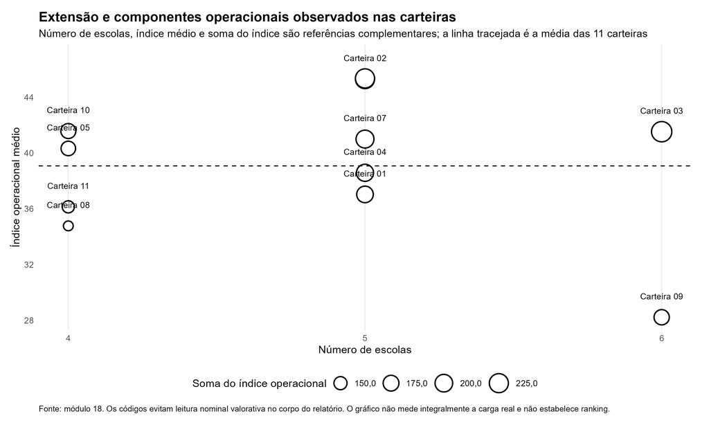

Figura 3: Extensão e intensidade relativa das carteiras

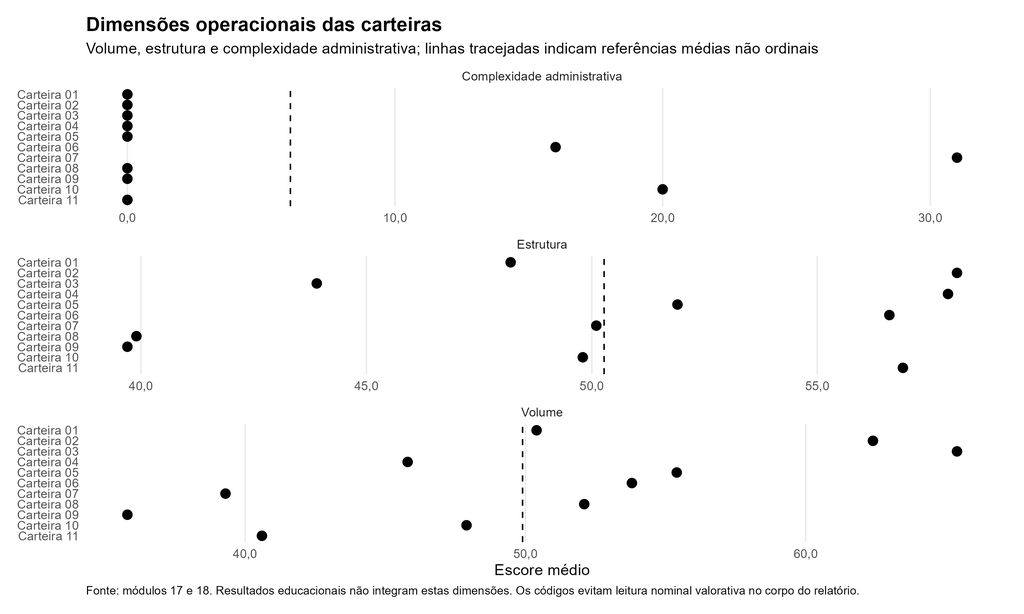

Figura 4: Composição das dimensões operacionais das carteiras

## Como usar essa informação

A gestão pode utilizar o diagnóstico para organizar uma **revisão técnica colegiada**, examinando:

- concentração de escolas de maior porte;
- presença de estruturas ou ofertas que exigem acompanhamento específico;
- combinação de complexidades administrativas;
- distância entre quantidade de escolas e volume potencial de demanda;
- conhecimento qualitativo das situações em curso;
- disponibilidade, experiência e especialização das assessoras.

O diagnóstico não autoriza uma redistribuição automática. Ele oferece uma linguagem comum para qualificar a discussão.

# Agenda recomendada

## 1. Imediato: pactuar regras de leitura

Formalizar que:

- escolas não operacionais não contam como carga;
- resultados educacionais não avaliam assessoras;
- o índice operacional não equivale à carga horária;
- diferenças entre carteiras não devem ser transformadas em ranking;
- decisões combinam evidência quantitativa e conhecimento profissional.

## 2. Curto prazo: revisar as carteiras em oficina técnica

Realizar uma oficina com a coordenação e a equipe de assessoras para:

1. examinar os perfis de escola e carteira;
2. registrar fatores qualitativos ainda ausentes nas bases;
3. identificar casos que merecem acompanhamento prioritário;
4. testar cenários de ajuste sem adotar automaticamente qualquer redistribuição;
5. documentar as justificativas das decisões.

## 3. Curto prazo: implantar registro mínimo do assessoramento

Criar instrumento padronizado por ação, contendo ao menos:

- escola;
- data;
- assessora;
- modalidade presencial ou remota;
- duração;
- tempo ou faixa de deslocamento;
- objetivo da ação;
- público envolvido;
- tema;
- encaminhamentos;
- necessidade de retorno;
- ocorrência emergencial;
- atividade realizada fora de uma escola específica.

Esse registro permitirá medir **dose**, **cobertura**, **frequência**, **intensidade** e **continuidade**.

## 4. Médio prazo: consolidar painel de gestão

O painel deve separar:

- estoque de escolas por carteira;
- fluxo de ações;
- horas diretas e indiretas;
- visitas e retornos;
- demanda emergencial;
- cobertura por escola;
- temas de assessoramento;
- alertas de escolas com baixa ou alta intensidade de acompanhamento.

## 5. Médio prazo: preparar avaliação futura

Uma avaliação de impacto mais robusta exigirá:

- medida de dose por escola e período;
- data de início e continuidade do acompanhamento;
- definição consistente do grupo elegível;
- resultados comparáveis no tempo;
- controle de cobertura e composição;
- estratégia de identificação previamente documentada.

# Riscos de interpretação

- **Desenho analítico:** O estudo é observacional e descritivo; não identifica efeitos causais.
- **Linha de base:** A primeira avaliação de 2025 ocorreu antes do assessoramento e representa dose zero.
- **Resultados educacionais:** Proficiência, adequação, defasagem e participação não integram o índice operacional.
- **Assessora:** Resultados das escolas não avaliam qualidade, produtividade ou efetividade das assessoras.
- **Participação e composição:** Qualquer descrição de desempenho deve ser acompanhada de cobertura e alertas de composição.
- **Índice operacional:** O índice é relativo e parcial; não representa integralmente horas, deslocamentos, emergências ou carga real.
- **Carteiras:** Comparações usam referências agregadas não ordinais e não classificam assessoras como sobrecarregadas ou subutilizadas.
- **Decisão gerencial:** Os produtos quantitativos subsidiam, mas não determinam automaticamente redistribuições.

# Decisões sugeridas à coordenação

1. **Homologar os quatro universos** como referência institucional.
2. **Adotar o diagnóstico como instrumento de discussão**, não como algoritmo de redistribuição.
3. **Determinar a implantação de registro mínimo das ações de assessoramento**.
4. **Realizar oficina técnica sobre as carteiras**, com documentação das conclusões.
5. **Manter os resultados educacionais fora da avaliação individual das assessoras**.
6. **Atualizar o diagnóstico periodicamente**, preservando versões, manifestos e critérios.
7. **Condicionar qualquer avaliação causal futura à disponibilidade de dose e desenho adequado**.

# Nota de rastreabilidade

Este documento utiliza exclusivamente produtos do pacote homologado:

- pacote: entrega_modulos_15_24_c770cf6_v001;
- execução do módulo 25: 20260803_003954;
- marco-base de desenvolvimento do módulo 26: 82a1a9c7c85f561db17a7855db58e7862904165e;
- validação integrada: **135 de 135 testes aprovados**;
- natureza: síntese gerencial derivada, sem recálculo de produtos analíticos.

O relatório técnico e os anexos permanecem as referências para detalhamento metodológico, tabelas completas e rastreabilidade.